# Презентация по лабораторной работе №3.

Простейший шаблон

Шияпова Д.И

Российский университет дружбы народов, Москва, Россия

Объединённый институт ядерных исследований, Дубна, Россия

24 февраля 2023 год

# Информация

## Докладчик

- Шияпова Дарина Илдаровна
- студент
- Российский университет дружбы народов

# Вводная часть

## Цели и задачи

Приобретение практических навыков взаимодействия пользователя с системой посредством командной строки.

# Выполнение лабораторной работы

## Переходим в каталог tmp и выводим содержание на экран

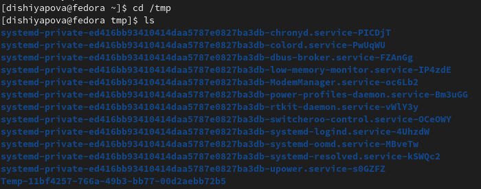

Использование команды ls

## С помощью команды ls -a выводим на экран содержание каталога включая скрытые файлы

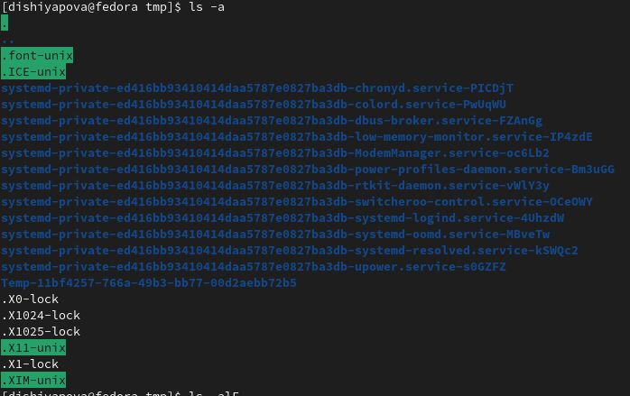

Использование команды ls -a

## С помощью команды ls -alF или команды ls -l выводим на экран содержание каталога и информацию о файлах.

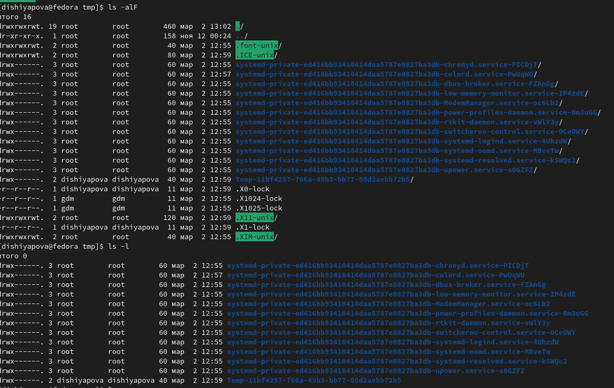

Использование команды ls -alF и команды ls -l

## С помощью команды ls -F выводим на экран содержание каталога и информацию о типе файла.

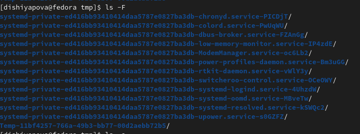

Использование команды ls -F

## Определяем есть ли в каталоге var/spool подкаталог с именем cron.

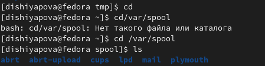

Такого файла нет

## Определяем кто является владельцем файлов и подкаталогов.

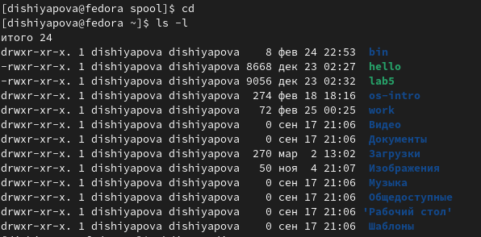

Владелец: dishiyapova

## Создаем в домашнем каталоге новый каталог newdir, после чего переходим в этот подкаталог и создаем еще один подкаталог morefun. Далее возвращаемся в домашний каталог и создаем три новый каталога letters memos misk и далее удаляем их.

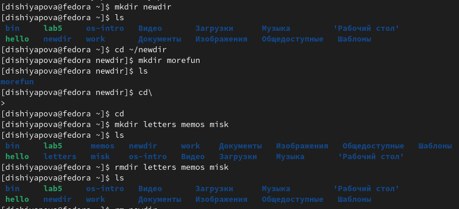

Создаем и удаляем каталоги

## Удаляем подкаталог morefun.

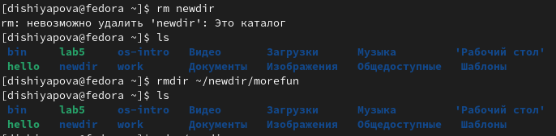

Использование команды rm и rmdir

## Команда ls -R выводит содержимое не только указанного каталога, но и подкаталогов, входящих в него.

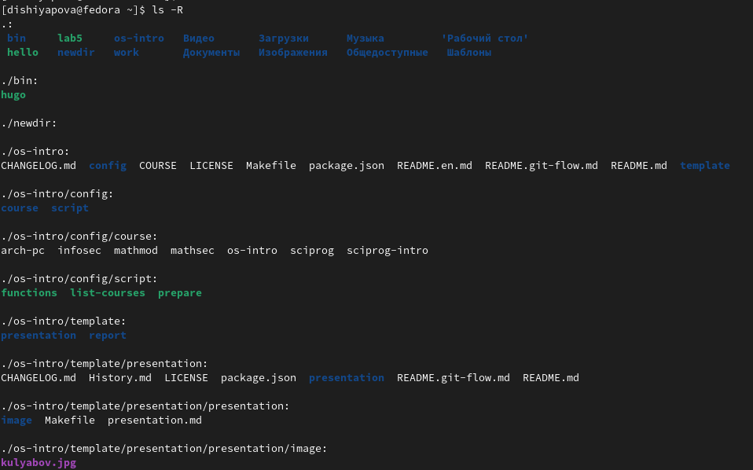

Использование команды ls -R

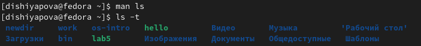

Использование команды ls -t

## Для вывода на экран списка ранее выполненных команд используется команда history. Выводимые на экран команды в списке нумеруются.

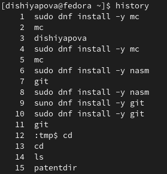

Использование команды history

## Используя информацию, полученную при помощи команды history, выполните модификацию и исполнение нескольких команд из буфера команд.

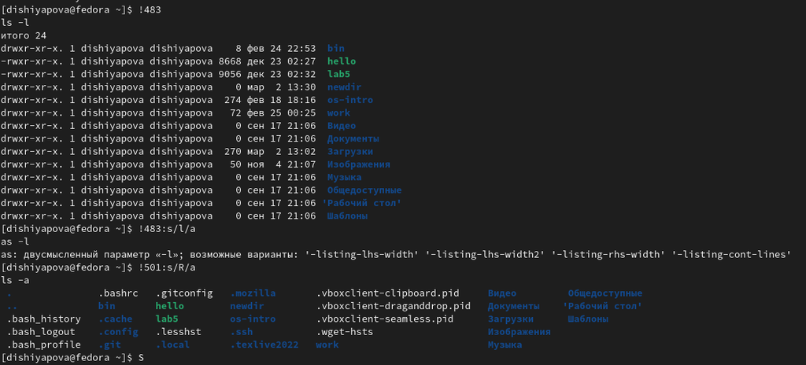

Использование команды history и специальной конструкции

# Выводы